# Red Wine Exploration by Julie Tang

========================================================

This report explores a dataset containing the quality and attributes of 1599 red wine samples.

# Univariate Plots Section

Check the structure of the dataset

```
## 'data.frame':    1599 obs. of  13 variables:
##  $ X                   : int  1 2 3 4 5 6 7 8 9 10 ...
##  $ fixed.acidity       : num  7.4 7.8 7.8 11.2 7.4 7.4 7.9 7.3 7.8 7.5 ...
##  $ volatile.acidity    : num  0.7 0.88 0.76 0.28 0.7 0.66 0.6 0.65 0.58 0.5 ...
##  $ citric.acid         : num  0 0 0.04 0.56 0 0 0.06 0 0.02 0.36 ...
##  $ residual.sugar      : num  1.9 2.6 2.3 1.9 1.9 1.8 1.6 1.2 2 6.1 ...
##  $ chlorides           : num  0.076 0.098 0.092 0.075 0.076 0.075 0.069 0.065 0.073 0.071 ...
##  $ free.sulfur.dioxide : num  11 25 15 17 11 13 15 15 9 17 ...
##  $ total.sulfur.dioxide: num  34 67 54 60 34 40 59 21 18 102 ...
##  $ density             : num  0.998 0.997 0.997 0.998 0.998 ...
##  $ pH                  : num  3.51 3.2 3.26 3.16 3.51 3.51 3.3 3.39 3.36 3.35 ...
##  $ sulphates           : num  0.56 0.68 0.65 0.58 0.56 0.56 0.46 0.47 0.57 0.8 ...
##  $ alcohol             : num  9.4 9.8 9.8 9.8 9.4 9.4 9.4 10 9.5 10.5 ...
##  $ quality             : int  5 5 5 6 5 5 5 7 7 5 ...
```

Check if there is any missing data in this dataset

```
##                    X        fixed.acidity     volatile.acidity
##                    0                    0                    0
##          citric.acid       residual.sugar            chlorides
##                    0                    0                    0
##  free.sulfur.dioxide total.sulfur.dioxide              density
##                    0                    0                    0
##                   pH            sulphates              alcohol
##                    0                    0                    0
##              quality
##                    0
```

Take a look at the summary data

```
##        X          fixed.acidity   volatile.acidity  citric.acid
##  Min.   :   1.0   Min.   : 4.60   Min.   :0.1200   Min.   :0.000
##  1st Qu.: 400.5   1st Qu.: 7.10   1st Qu.:0.3900   1st Qu.:0.090
##  Median : 800.0   Median : 7.90   Median :0.5200   Median :0.260
##  Mean   : 800.0   Mean   : 8.32   Mean   :0.5278   Mean   :0.271
##  3rd Qu.:1199.5   3rd Qu.: 9.20   3rd Qu.:0.6400   3rd Qu.:0.420
##  Max.   :1599.0   Max.   :15.90   Max.   :1.5800   Max.   :1.000
##  residual.sugar     chlorides       free.sulfur.dioxide total.sulfur.dioxide
##  Min.   : 0.900   Min.   :0.01200   Min.   : 1.00       Min.   :  6.00
##  1st Qu.: 1.900   1st Qu.:0.07000   1st Qu.: 7.00       1st Qu.: 22.00
##  Median : 2.200   Median :0.07900   Median :14.00       Median : 38.00
##  Mean   : 2.539   Mean   :0.08747   Mean   :15.87       Mean   : 46.47
##  3rd Qu.: 2.600   3rd Qu.:0.09000   3rd Qu.:21.00       3rd Qu.: 62.00
##  Max.   :15.500   Max.   :0.61100   Max.   :72.00       Max.   :289.00
##     density             pH          sulphates         alcohol
##  Min.   :0.9901   Min.   :2.740   Min.   :0.3300   Min.   : 8.40
##  1st Qu.:0.9956   1st Qu.:3.210   1st Qu.:0.5500   1st Qu.: 9.50
##  Median :0.9968   Median :3.310   Median :0.6200   Median :10.20
##  Mean   :0.9967   Mean   :3.311   Mean   :0.6581   Mean   :10.42
##  3rd Qu.:0.9978   3rd Qu.:3.400   3rd Qu.:0.7300   3rd Qu.:11.10
##  Max.   :1.0037   Max.   :4.010   Max.   :2.0000   Max.   :14.90
##     quality
##  Min.   :3.000
##  1st Qu.:5.000
##  Median :6.000
##  Mean   :5.636
##  3rd Qu.:6.000
##  Max.   :8.000
```

Our dataset consists of 13 variables and 1599 samples.The data type of every attribute is good and there is no missing data in this dataset. The output variable, quality, is our interest to analyze.

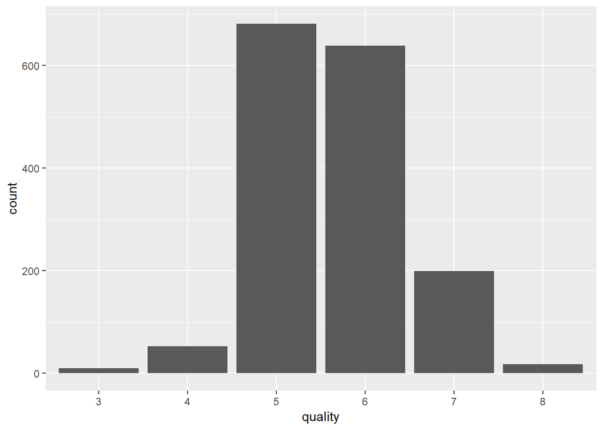

```
##    Min. 1st Qu.  Median    Mean 3rd Qu.    Max.
##   3.000   5.000   6.000   5.636   6.000   8.000
```

```
##
##   3   4   5   6   7   8
##  10  53 681 638 199  18
```

Quality is a discrete quantitative variable. The range of quality variable is from 3(lowest) to 8(highest). And the most common level of qualities are 5 and 6. 681 samples’ quality rate is 5 and 638 samples’ quality rate is 6.

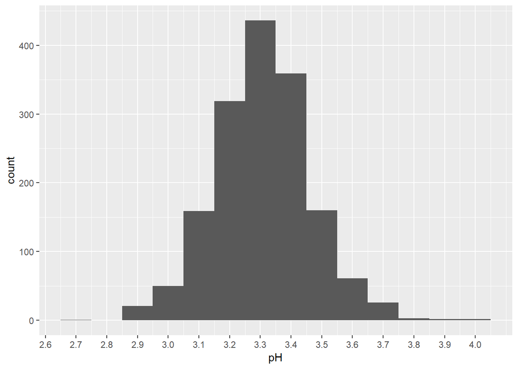

```
##    Min. 1st Qu.  Median    Mean 3rd Qu.    Max.
##   2.740   3.210   3.310   3.311   3.400   4.010
```

The pH is normal distributed. The mean is 3.311 and the median is 3.310, which are very close. According to some experts’ opinion, pH is one of the most important attributes on the wine’s quality. It affects almost every aspect of the wine, including the quality. I wondered what’s its correlation with quality in our dataset.

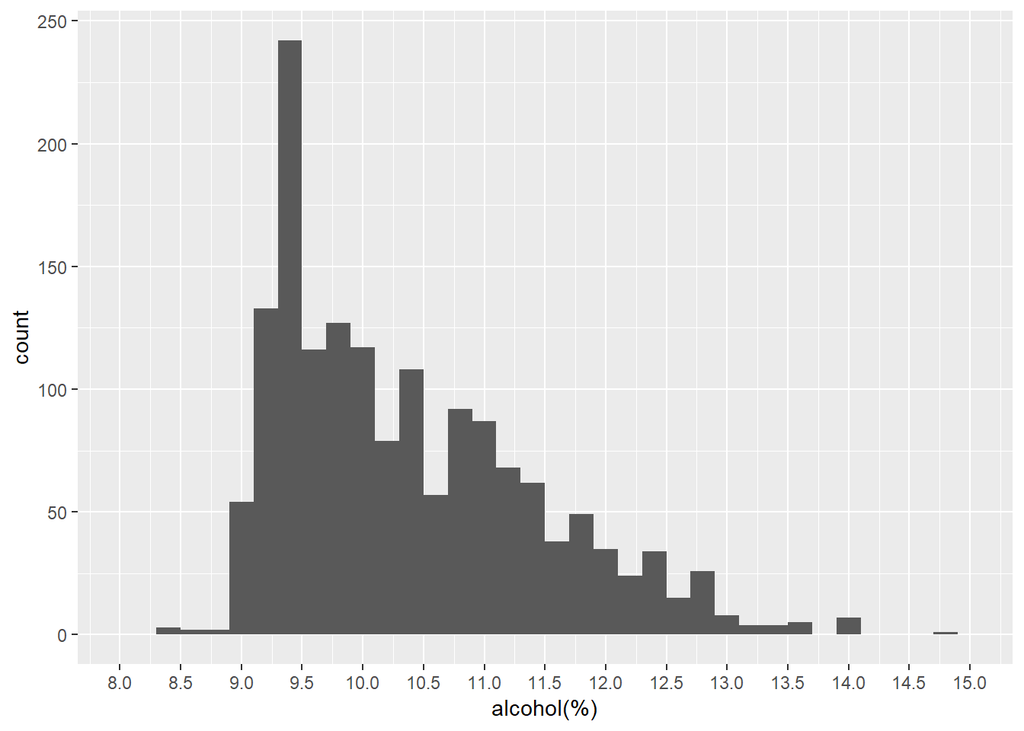

Try log10 transformation since the alcohol distribution is right skewed

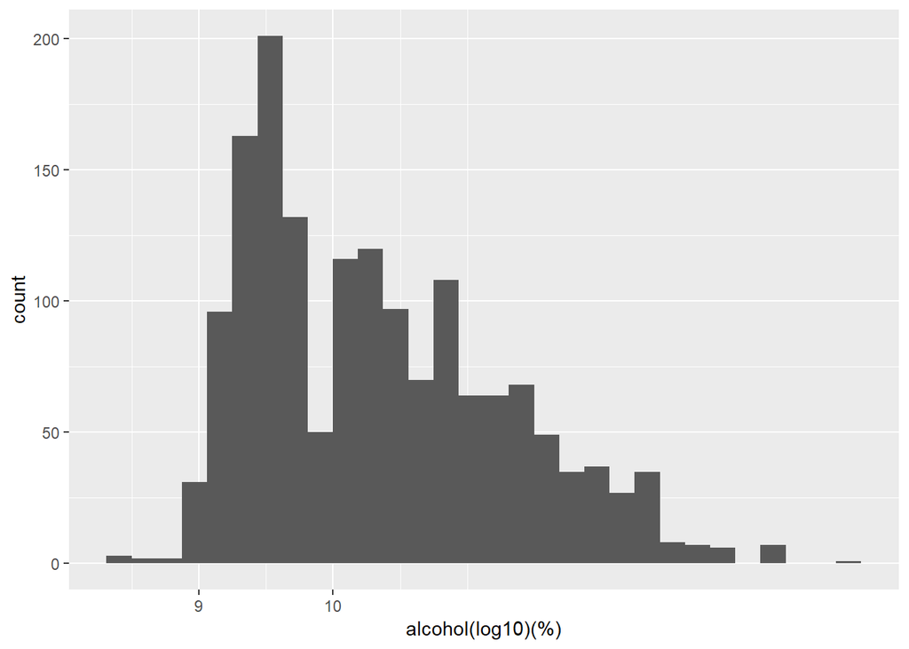

Try square root transformation to see if it will be more close to normal distribution.

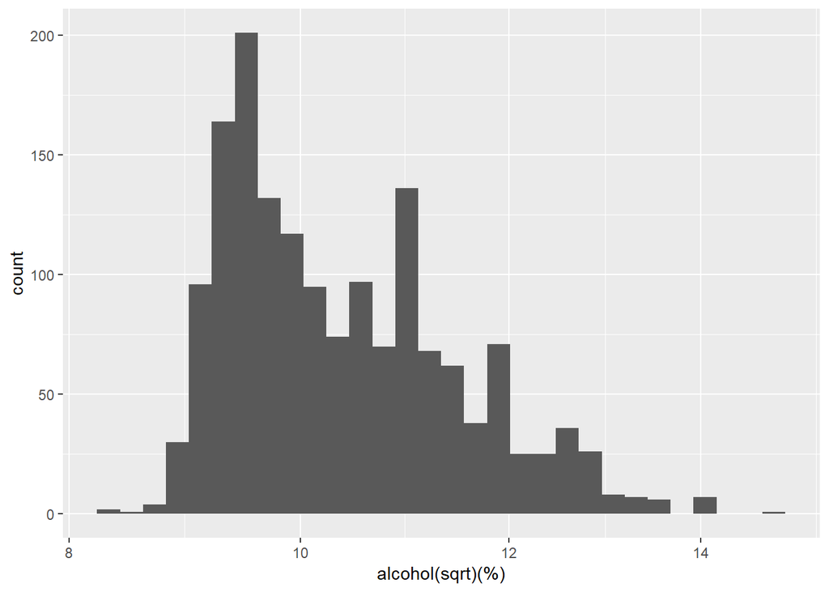

```
##    Min. 1st Qu.  Median    Mean 3rd Qu.    Max.
##    8.40    9.50   10.20   10.42   11.10   14.90
```

The distribution of percent alcohol content is right skewed. I tried to use log and square root transformation but the distribution was still right skewed. It seems the transformation doesn’t affect it much. From the plot and summary data, we can see the median value of percent alcohol content is about 10.

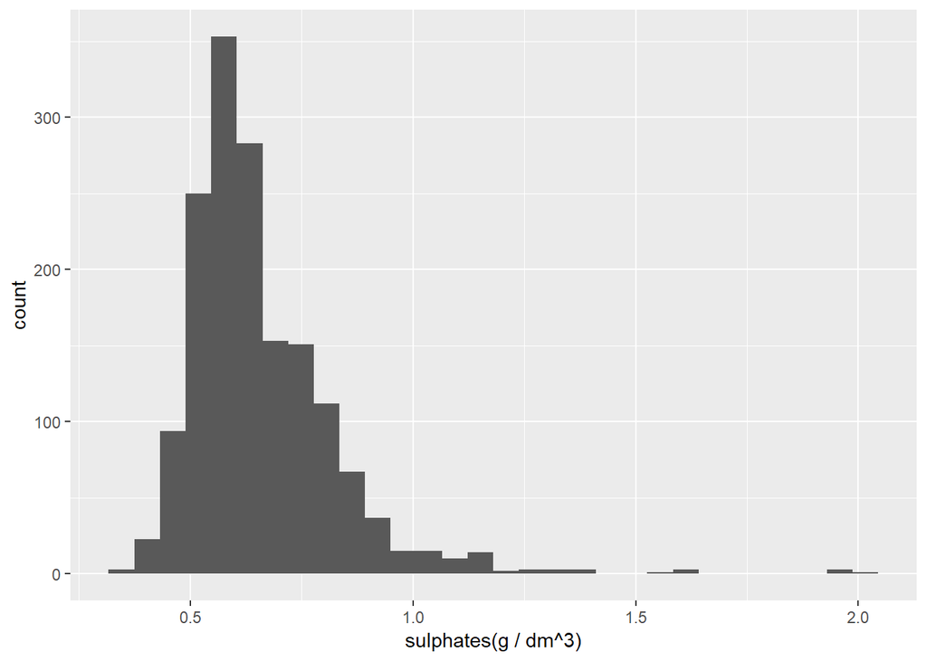

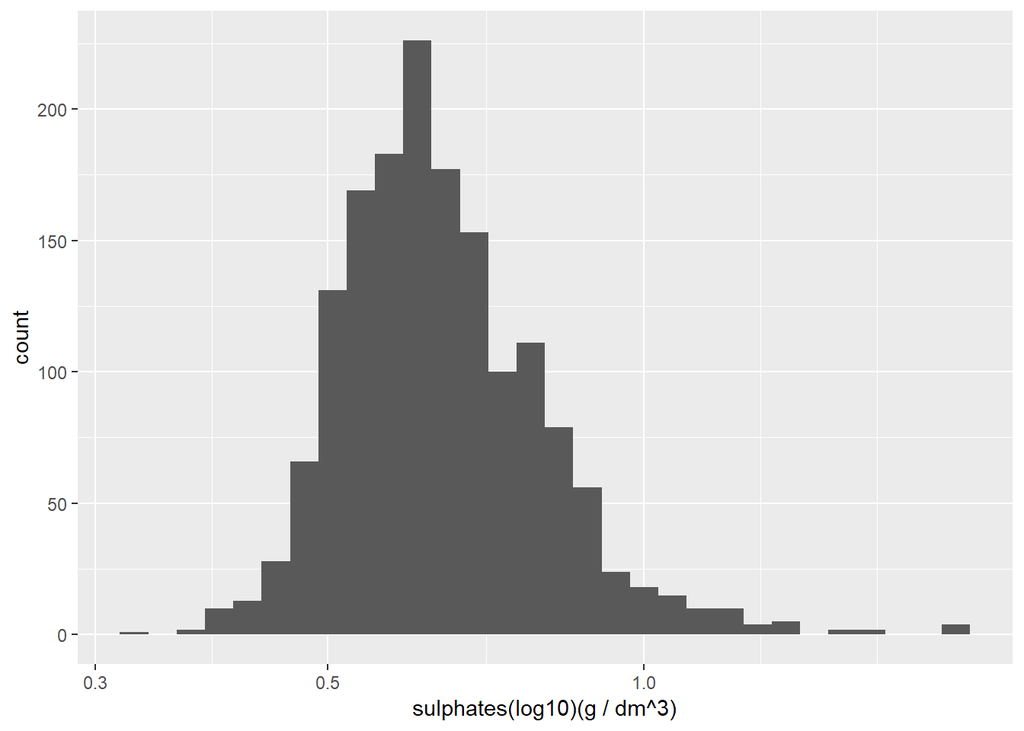

```
##    Min. 1st Qu.  Median    Mean 3rd Qu.    Max.
##  0.3300  0.5500  0.6200  0.6581  0.7300  2.0000
```

The distribution of sulphates is also right skewed. With log10 transformation, its distribution is normal. From the plot we can see most of samples have sulphates under 1.0. But there are some outliers with value much higher.

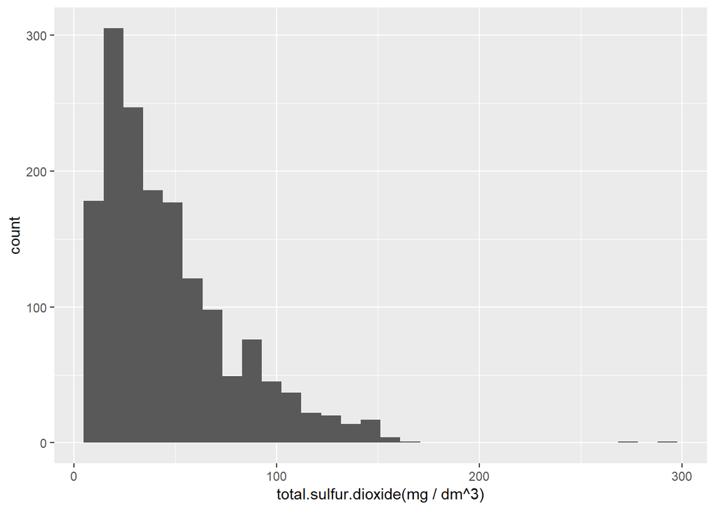

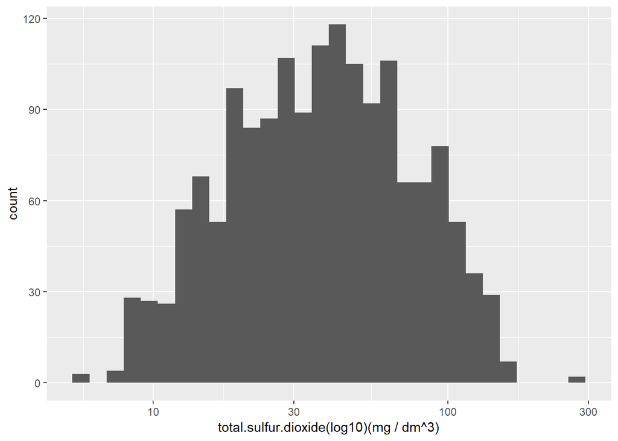

```
##    Min. 1st Qu.  Median    Mean 3rd Qu.    Max.
##    6.00   22.00   38.00   46.47   62.00  289.00
```

The distribution of total sulfur dioxide is also right skewed. With log10 transformation, its distribution is close to normal. From the plot we can see most of samples have total sulfur dioxide under 100. But there are a few outliers with value around 300!

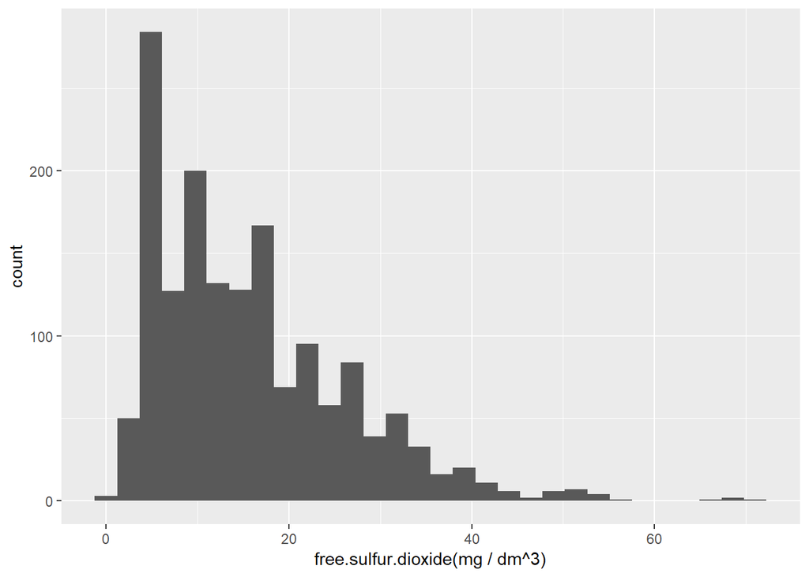

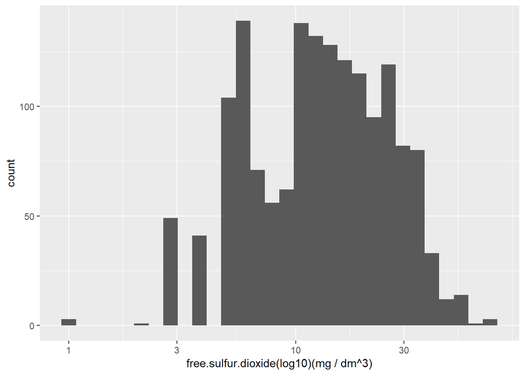

```
##    Min. 1st Qu.  Median    Mean 3rd Qu.    Max.
##    1.00    7.00   14.00   15.87   21.00   72.00
```

The distribution of free sulfur dioxide has multiple peaks after log10 transformation. One is around 7, the second is around 14 and the third is around 30.

Create a new variable (all.sulphates) by adding up total.sulfur.dioxide and sulphates * 1000.

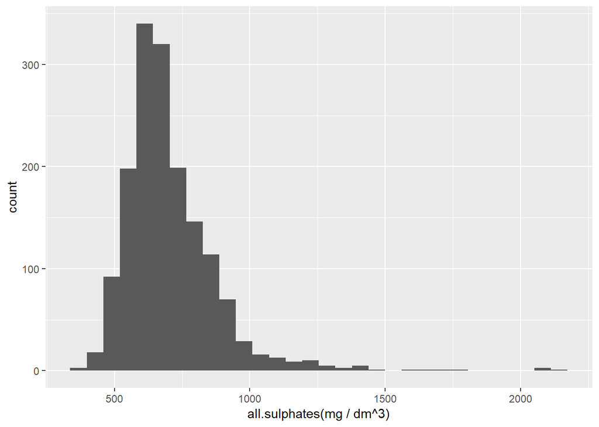

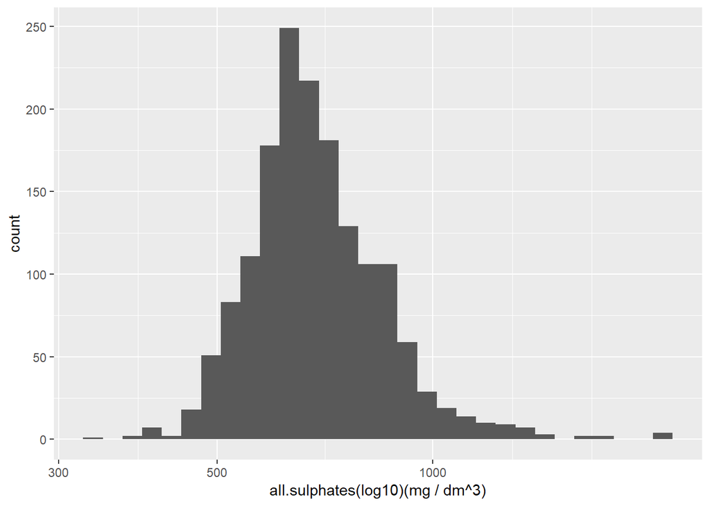

```
##    Min. 1st Qu.  Median    Mean 3rd Qu.    Max.
##   338.0   598.0   670.0   704.6   778.0  2113.0
```

Since sulfur dioxide is just another type of sulphates. I think maybe we can add them up to create a new variable, all.sulphates, and check the correlation of this new variable with quality.

The distribution of Sulphates, total.sulfur.dioxide, free.sulfur.dioxide and all.sulphates are all right skewed. With the log transformation, they are close to normal distribution. There are some outliers with very high free.sulfur.dioxide and total.sulfur.dioxide. A new variable (all.surphates) is created to store the total sulphates content in the sample.

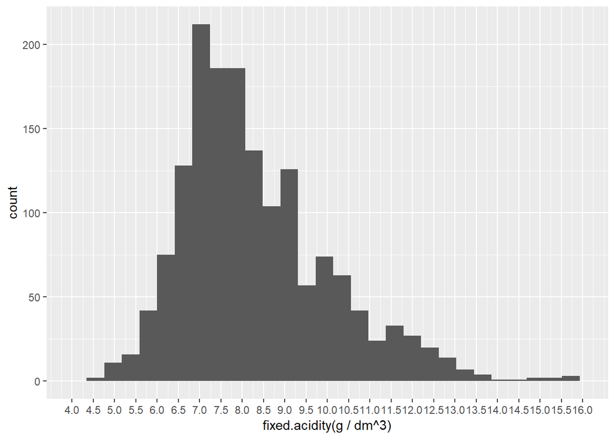

```
##    Min. 1st Qu.  Median    Mean 3rd Qu.    Max.
##    4.60    7.10    7.90    8.32    9.20   15.90
```

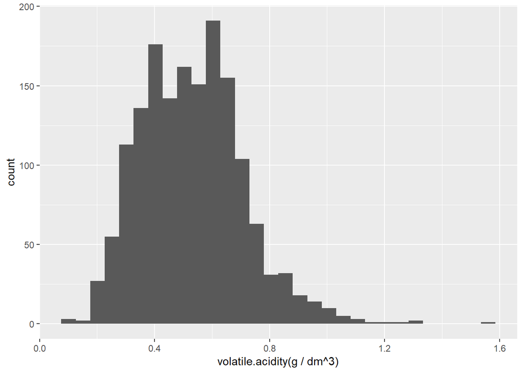

```
##    Min. 1st Qu.  Median    Mean 3rd Qu.    Max.
##  0.1200  0.3900  0.5200  0.5278  0.6400  1.5800
```

The distribution of both fixed.acidity and volatile.acidity are close to normal distribution. But both have some outstanding outliers on upper side.

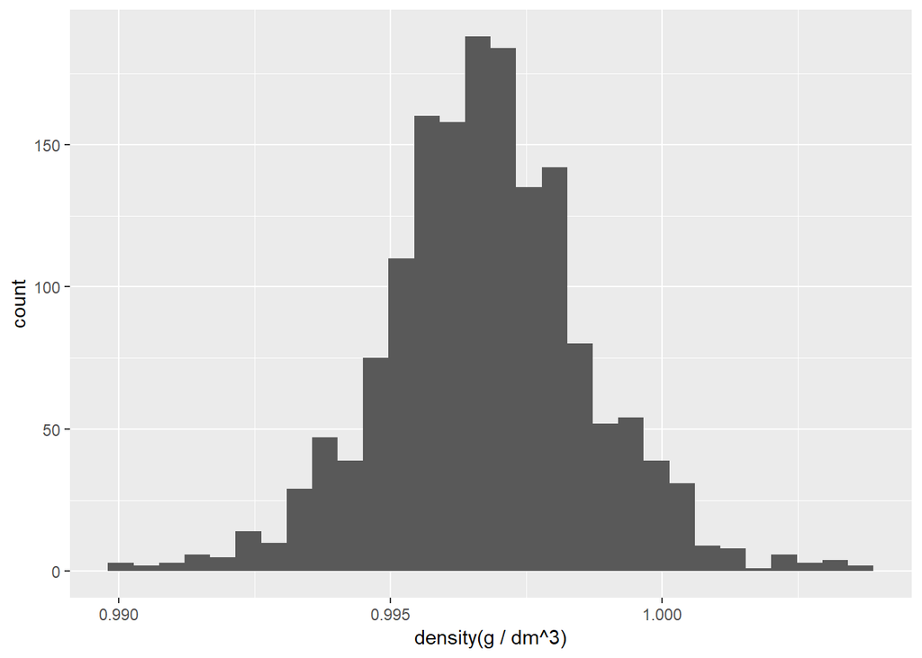

```
##    Min. 1st Qu.  Median    Mean 3rd Qu.    Max.
##  0.9901  0.9956  0.9968  0.9967  0.9978  1.0037
```

The distribution of density is normal. And the range is very very small (from 0.9901 to 1.0037). It seems it doesn’t impact the quality much.

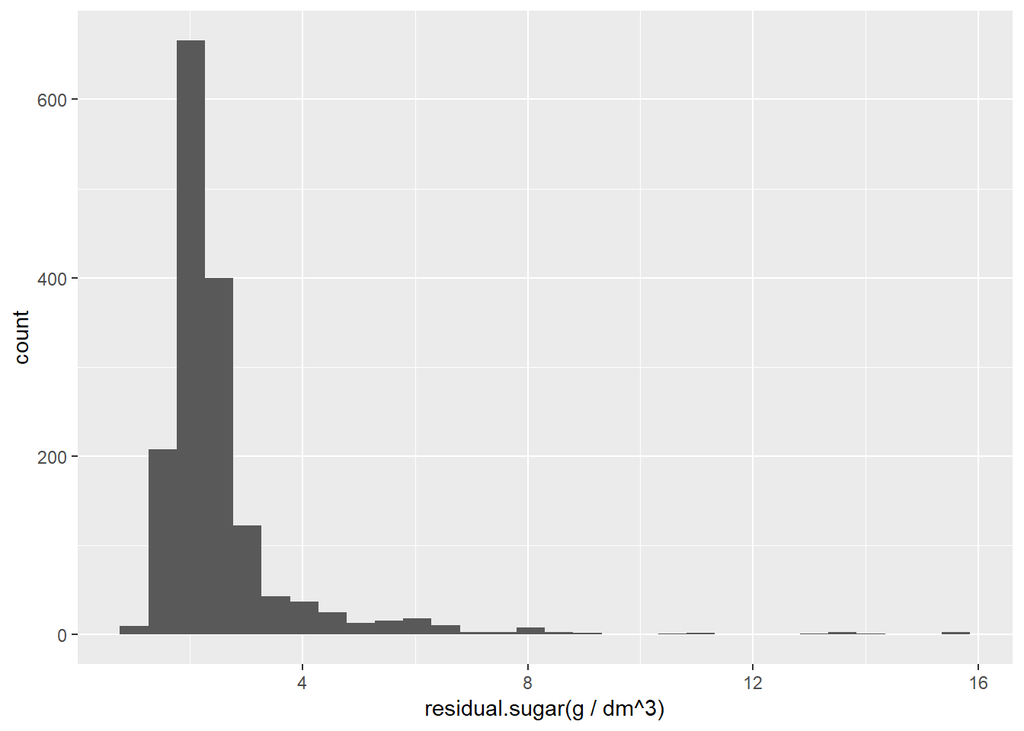

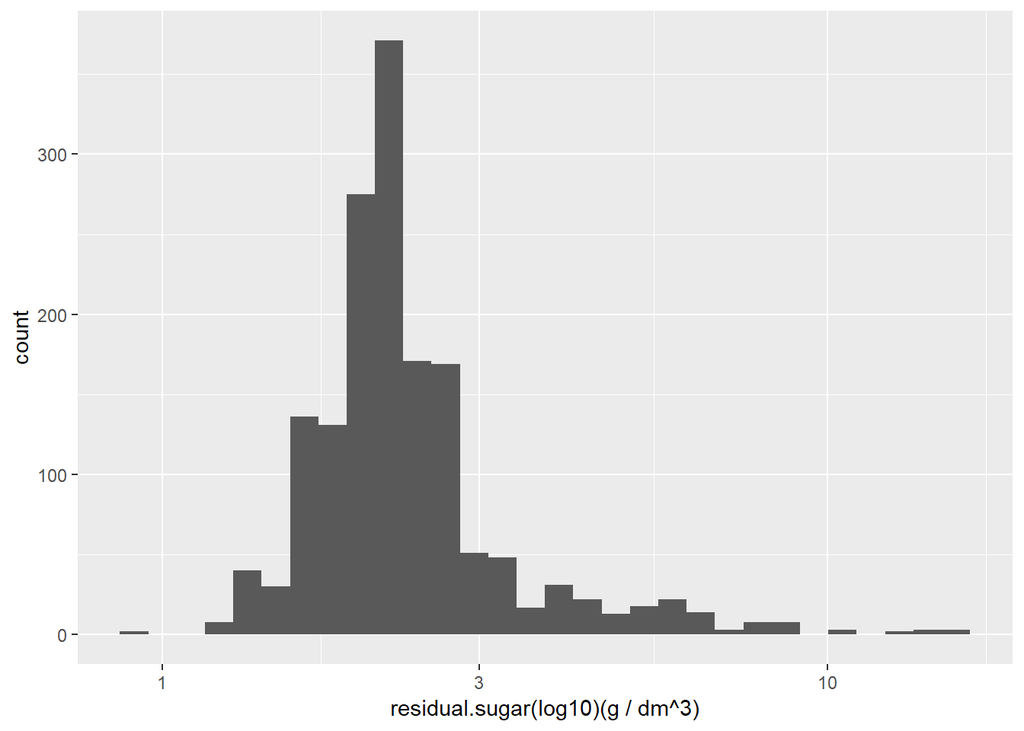

```
##    Min. 1st Qu.  Median    Mean 3rd Qu.    Max.
##   0.900   1.900   2.200   2.539   2.600  15.500
```

The distribution of residual sugar is right skewed. With the log transformation, it’s better but still kind of right skewed. And the most of sample’s sugar level is between 2 and 3.

# Univariate Analysis

### What is the structure of your dataset?

There are 1599 samples in the dataset with 13 variables. 11 are attributes that might impact the quality (fixed.acidity, volatile.acidity,, citric.acid, residual.sugar, chlorides, free.sulfur.dioxide, total.sulfur.dioxide, density, pH, sulphates and alcohol). All these attributes are quantitative variables. Variable quality is the output variable, which is also the one we are intersted in. Quality is also quantified.

Other observations:  
1. Most of samples’ quality rate is 5 or 6.  
2. The density of all samples are very close. It has a very narrow range(from 0.9901 to 1.0037). It seems it doesn’t impact the quality much.  
3. The median percent alcohol content is 10.2. But there are a few outlier with value higher than 14.  
4. The median pH value is 3.31 and it’s normal distributed.  
5. There are some outliers with very high free.sulfur.dioxide and total.sulfur.dioxide. Since high sulphates is not good for health and according to experts’ opinion, it impact the taste of the wine too. Does higher wine quality generally have lower sulphate/Sulfur dioxide content?

### What is/are the main feature(s) of interest in your dataset?

The main feature of interest in the dataset is quality. I want to check which attributes have most important impact on the wine’s quality.

### What other features in the dataset do you think will help support your investigation into your feature(s) of interest?

Acidity, residual sugar, chlorides, sulfur dioxide, density, pH, sulphates and alcohol likely all contribute to the quality of red wine. I think pH and sulphates might contribute most to the quality according to some experts’ opinion on the wine quality.

### Did you create any new variables from existing variables in the dataset?

Yes. I created a new variables named “all.sulphates”. Since sulfur dioxide is just another type of sulphates, I think it makes sense to add them up together to see what impact they have on the quality.

# Bivariate Plots Section

Remove the first variable (X) before generating the correlation matrix, since X is just an id for every sample

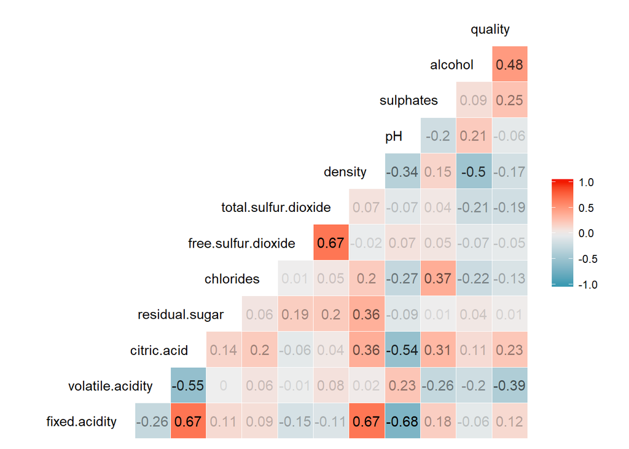

From the correlation matrix above, it looks to me that many attributes tend to correlate with each other and also correlate with quality. But I don’t see either two have very strong correlation. I think it may be because the wine quality somehow is very difficult to accurately describe and quantify. I suppose pH and sulphates impact the quality most according to the articles I read from the website. However, from this plot, it looks alcohol has most correlation with the quality, very interesting.

```
## red_wine$quality: 3
##    Min. 1st Qu.  Median    Mean 3rd Qu.    Max.
##   3.160   3.312   3.390   3.398   3.495   3.630
## ------------------------------------------------------------
## red_wine$quality: 4
##    Min. 1st Qu.  Median    Mean 3rd Qu.    Max.
##   2.740   3.300   3.370   3.382   3.500   3.900
## ------------------------------------------------------------
## red_wine$quality: 5
##    Min. 1st Qu.  Median    Mean 3rd Qu.    Max.
##   2.880   3.200   3.300   3.305   3.400   3.740
## ------------------------------------------------------------
## red_wine$quality: 6
##    Min. 1st Qu.  Median    Mean 3rd Qu.    Max.
##   2.860   3.220   3.320   3.318   3.410   4.010
## ------------------------------------------------------------
## red_wine$quality: 7
##    Min. 1st Qu.  Median    Mean 3rd Qu.    Max.
##   2.920   3.200   3.280   3.291   3.380   3.780
## ------------------------------------------------------------
## red_wine$quality: 8
##    Min. 1st Qu.  Median    Mean 3rd Qu.    Max.
##   2.880   3.163   3.230   3.267   3.350   3.720
```

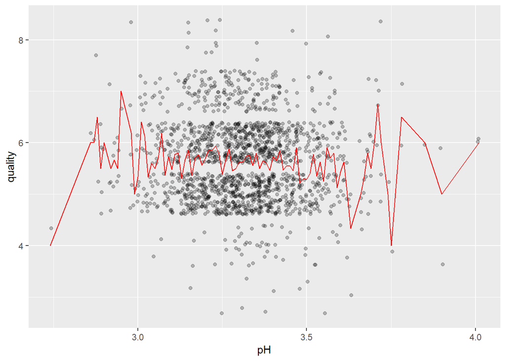

```
##
##  Pearson's product-moment correlation
##
## data:  red_wine$pH and red_wine$quality
## t = -2.3109, df = 1597, p-value = 0.02096
## alternative hypothesis: true correlation is not equal to 0
## 95 percent confidence interval:
##  -0.106451268 -0.008734972
## sample estimates:
##         cor
## -0.05773139
```

From the scatter plot above, I can’t tell if there is any correlation between pH and quailty. The Peason’s correlation test also shows there is very week correlation between them. The correlation value is just -0.058. Surprised!

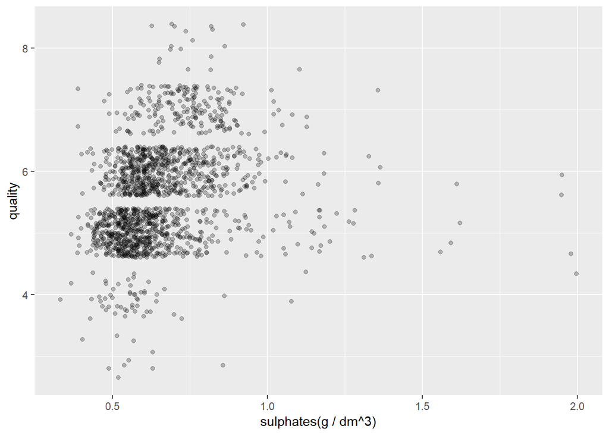

Do a log10 transformation and only check the 95% of sulphates data to see if the shape will be better.

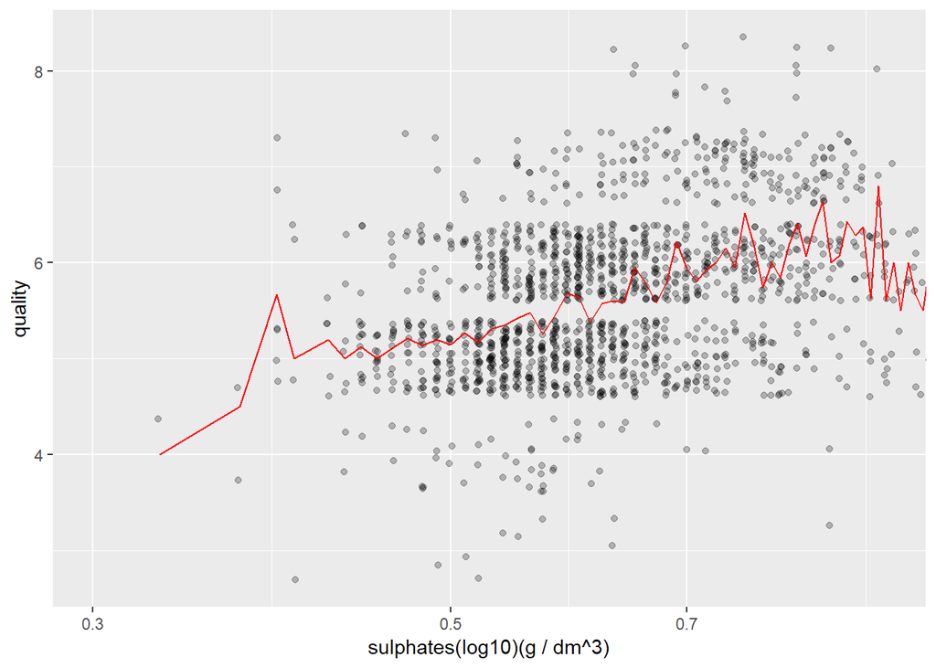

```
## red_wine$quality: 3
##    Min. 1st Qu.  Median    Mean 3rd Qu.    Max.
##  0.4000  0.5125  0.5450  0.5700  0.6150  0.8600
## ------------------------------------------------------------
## red_wine$quality: 4
##    Min. 1st Qu.  Median    Mean 3rd Qu.    Max.
##  0.3300  0.4900  0.5600  0.5964  0.6000  2.0000
## ------------------------------------------------------------
## red_wine$quality: 5
##    Min. 1st Qu.  Median    Mean 3rd Qu.    Max.
##   0.370   0.530   0.580   0.621   0.660   1.980
## ------------------------------------------------------------
## red_wine$quality: 6
##    Min. 1st Qu.  Median    Mean 3rd Qu.    Max.
##  0.4000  0.5800  0.6400  0.6753  0.7500  1.9500
## ------------------------------------------------------------
## red_wine$quality: 7
##    Min. 1st Qu.  Median    Mean 3rd Qu.    Max.
##  0.3900  0.6500  0.7400  0.7413  0.8300  1.3600
## ------------------------------------------------------------
## red_wine$quality: 8
##    Min. 1st Qu.  Median    Mean 3rd Qu.    Max.
##  0.6300  0.6900  0.7400  0.7678  0.8200  1.1000
```

```
##
##  Pearson's product-moment correlation
##
## data:  red_wine$sulphates and red_wine$quality
## t = 10.38, df = 1597, p-value < 2.2e-16
## alternative hypothesis: true correlation is not equal to 0
## 95 percent confidence interval:
##  0.2049011 0.2967610
## sample estimates:
##       cor
## 0.2513971
```

It’s very hard to tell if there is any relationship between the sulphates and quality from the first scatter plot. By log10 transformationSince most samples and look closer to the data(95%), we can see the mean quality is a slightly trending up along with sulphate value. This is also surprising since I suppose higher quality has lower sulphate content. The correlation value is 0.251, which indicates a weak correlation.

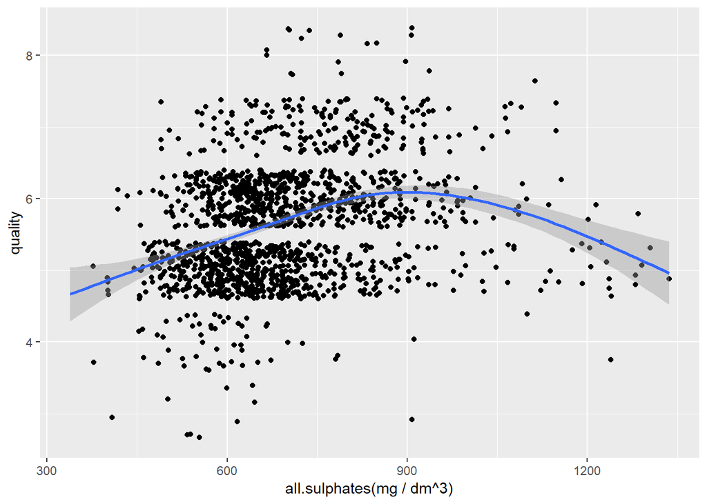

```
##
##  Pearson's product-moment correlation
##
## data:  red_wine$all.sulphates and red_wine$quality
## t = 8.5771, df = 1597, p-value < 2.2e-16
## alternative hypothesis: true correlation is not equal to 0
## 95 percent confidence interval:
##  0.1625010 0.2562357
## sample estimates:
##       cor
## 0.2098504
```

It seems it’s not good idea to combine sulphates and sulfur dioxide. With the combined sulphates I don’t see there is any obvious correlation between sulphates and quality, also the correlation value decreased from 0.251 to 0.21. Maybe we should look sulphates and sulfur dioxide data separately.

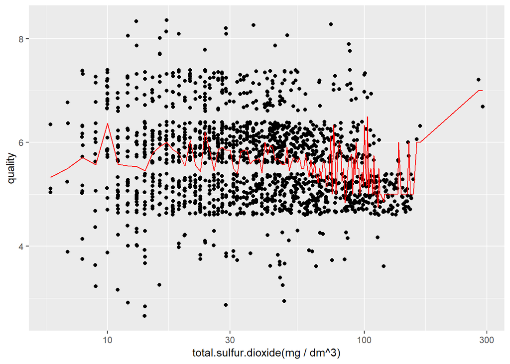

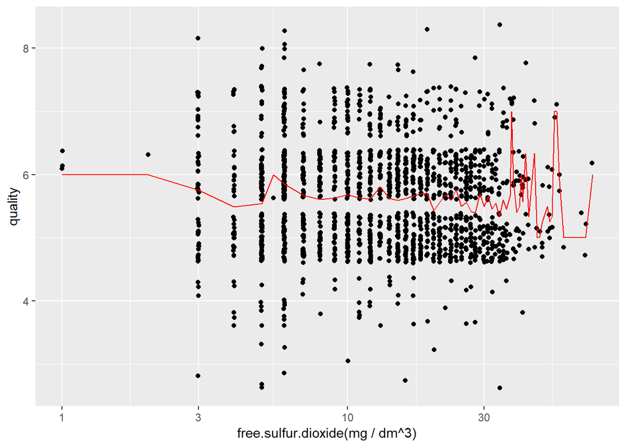

yes, it looks either free sulfur dioxide or total sulfur dioxide content impact the quality much. But Sulphates content does look be correlated, though not strong, with the quality level.

From the pairs plot, I noticed there are some other interesting relationships between the attributes. For example fixed.acidity and pH, fixed.acidity and density, fixed.acidity and citric.acid, free.sulfur.dioxide and total.sulfur.dioxide.

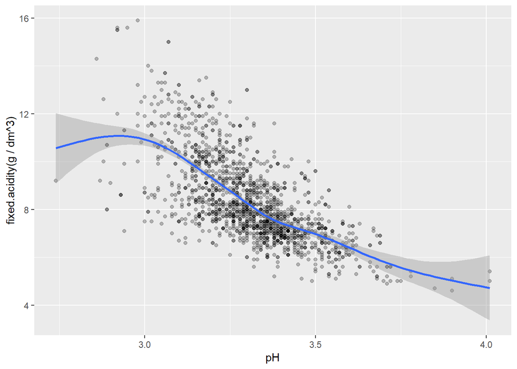

```
##
##  Pearson's product-moment correlation
##
## data:  red_wine$pH and red_wine$fixed.acidity
## t = -37.366, df = 1597, p-value < 2.2e-16
## alternative hypothesis: true correlation is not equal to 0
## 95 percent confidence interval:
##  -0.7082857 -0.6559174
## sample estimates:
##        cor
## -0.6829782
```

Both the scatter plot and the Pearson’s correlation test show there are negative correlation between the pH and fixed.acidity. The higher pH the lower acidity. And the correlation is strong ( -0.683).

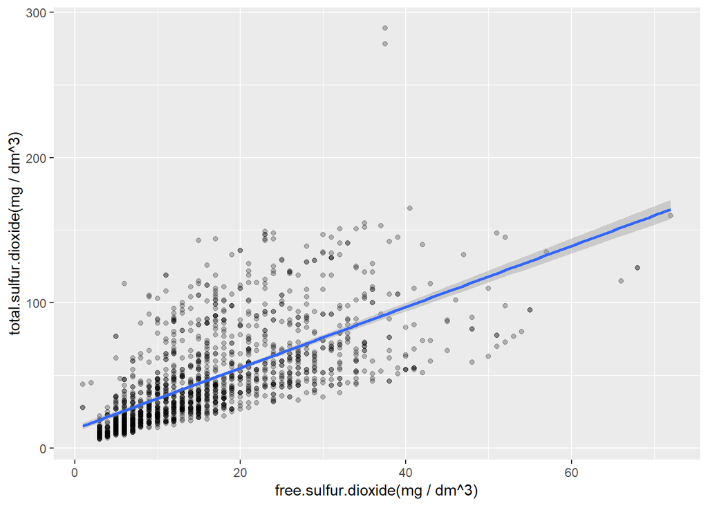

```
##
##  Pearson's product-moment correlation
##
## data:  red_wine$free.sulfur.dioxide and red_wine$total.sulfur.dioxide
## t = 35.84, df = 1597, p-value < 2.2e-16
## alternative hypothesis: true correlation is not equal to 0
## 95 percent confidence interval:
##  0.6395786 0.6939740
## sample estimates:
##       cor
## 0.6676665
```

```
##
## Calls:
## m1: lm(formula = total.sulfur.dioxide ~ free.sulfur.dioxide, data = red_wine)
##
## ======================================
##   (Intercept)              13.135***
##                            (1.114)
##   free.sulfur.dioxide       2.100***
##                            (0.059)
## --------------------------------------
##   R-squared                 0.446
##   adj. R-squared            0.445
##   sigma                    24.497
##   F                      1284.519
##   p                         0.000
##   Log-likelihood        -7382.361
##   Deviance             958359.610
##   AIC                   14770.721
##   BIC                   14786.852
##   N                      1599
## ======================================
```

The scatter plot and Pearson’s correlation test both show there are strong correlation between free sulfur dioxide content and total sulfur dioxide content. And it’s close to a linear model. By creating the linear model however it can only explain 44.6% of the result. It looks it’s not a strong linear relationship.

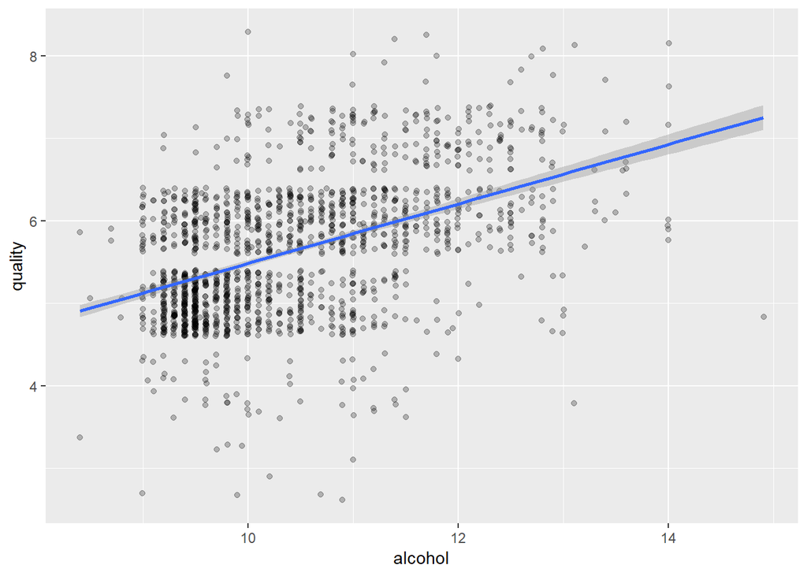

```
##
##  Pearson's product-moment correlation
##
## data:  red_wine$alcohol and red_wine$quality
## t = 21.639, df = 1597, p-value < 2.2e-16
## alternative hypothesis: true correlation is not equal to 0
## 95 percent confidence interval:
##  0.4373540 0.5132081
## sample estimates:
##       cor
## 0.4761663
```

Among all the attributes, alcohol has the strongest correlation (0.476) with quality. I’m surprised since Alcohol is never mentioned in the articles I have read.

# Bivariate Analysis

### Did you observe any interesting relationships between the other features (not the main feature(s) of interest)?

Yes. There are some interesting relationships between the attributes. * There are negative correlation between fixed.acidity and pH, the higher pH the lower acidity. * Between free.sulfur.dioxide and total.sulfur.dioxide, Generally higher free sulfur dioxide higher total sulfur dioxide. This is easy to understand.

### What was the strongest relationship you found?

The strongest relationship I found is between attribute fixed.acidity and pH. Its correlation value is -0.6829782.

# Multivariate Plots Section

```
##
## (2,4] (4,6] (6,8]
##    63  1319   217
```

Quality rates are categorized into 3 buckets: (2,4] low quality; (4,6] Medium quality; (6, 8] high quality to assist the analysis of multiple variables.

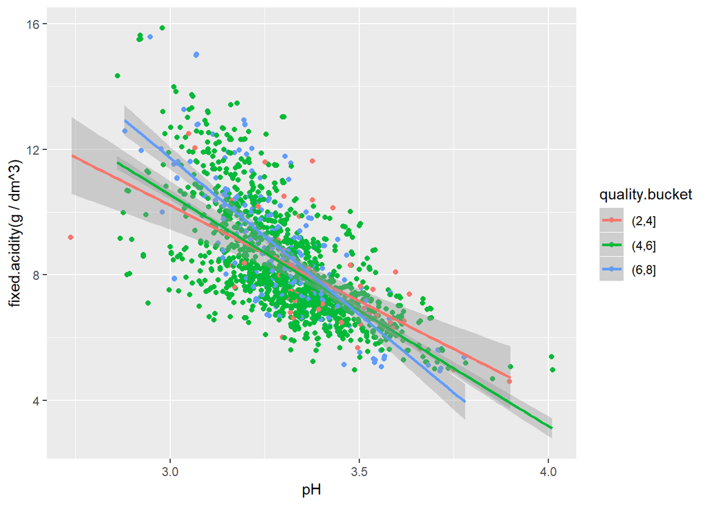

It shows the pH and fixed acidity have negative correlation in all three quality buckets.

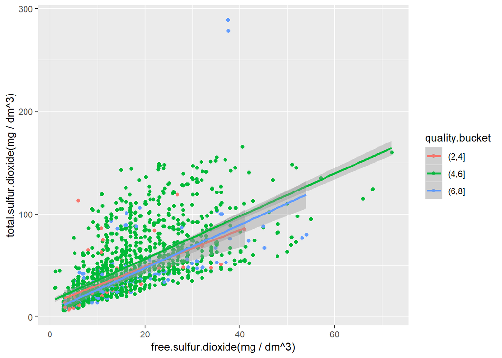

It shows the free sulfur dioxide and total sulfur dioxide have positive correlation in all three quality buckets.

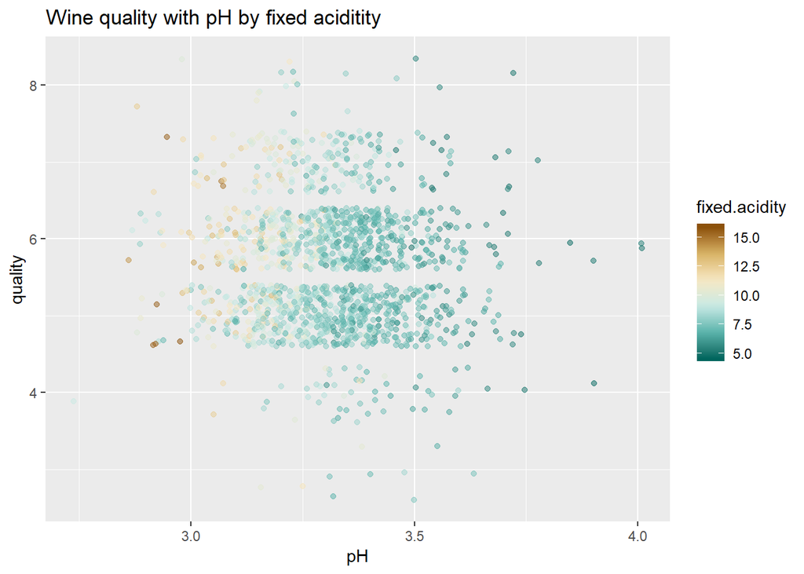

I can’t tell there is much correlation between pH and quality from this scatter plot. But after adding the fixed acidity, we can see higher fixed acidity is on the left, associated with lower pH. It’s becauase fixed acidity are negatively correlated with pH.